# DATA 402 HW 2

Author

Sophia Chung

#### Section A: Theory

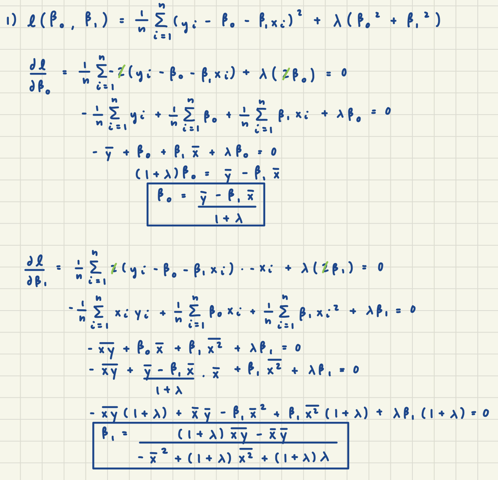

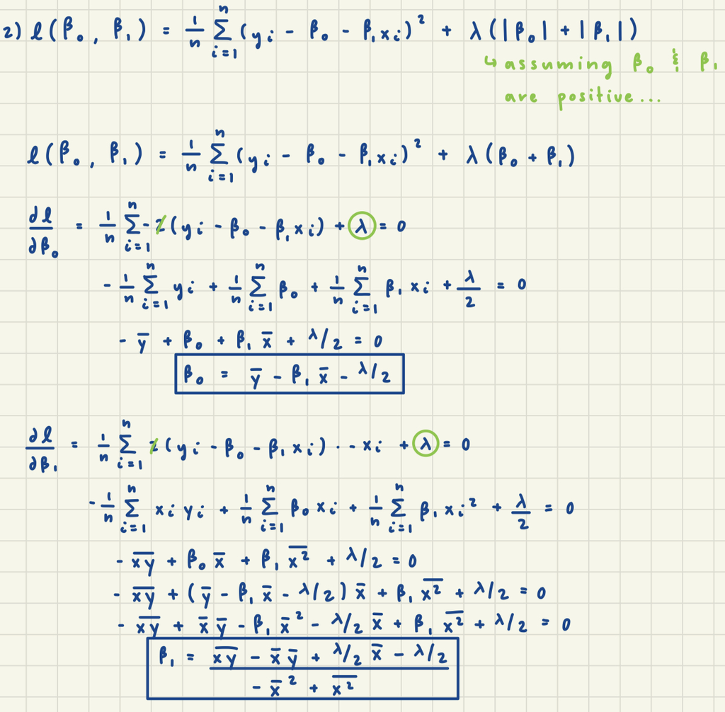

#### Section B: Coding

```r
ames <- read.csv('/Users/sophiapchung/Desktop/DATA 402/HW2/AmesHousing.csv')
```

##### 1)

```r
ridge_estimator <- function(x, y, lambda) {
  x <- as.double(x)
  y <- as.double(y)
  b1 <- ((1 + lambda) * mean(x * y) - mean(x) * mean(y)) /
    (-mean(x)^2 + (1 + lambda) * mean(x^2) + (1 + lambda) * lambda)
  b0 <- (mean(y) - b1 * mean(x)) / (1 + lambda)
  return (c(b0, b1))
}
```

##### 2)

```r
try_many_lambdas <- function(x, y, lambdas) {
  df <- data.frame(matrix(nrow=0, ncol=3))
  colnames(df) <- c('lambda', 'b0', 'b1')
  for (i in 1:length(lambdas)) {
    estimates <- ridge_estimator(x, y, lambdas[i])
    new <- data.frame('lambda'=lambdas[i], 'b0'=estimates[1], 'b1'=estimates[2])
    df <- rbind(df, new)
  }
  return (df)
}
```

##### 3)

```r
tune_lambda_classic <- function(x, y, lambdas, metric) {
  estimators <- try_many_lambdas(x, y, lambdas)
  metrics <- c()
  for (i in 1:length(lambdas)) {
    pred <- estimators[i, 'b0'] + estimators[i, 'b1'] * x
    if (metric == 'Adjusted R-squared') {
      r2 <- 1 - sum((y - pred)^2)/sum((y - mean(y))^2)

      n <- length(y)
      p <- 1 # number of independent vars
      adj_r2 <- 1 - ((1 - r2) * (n - 1))/(n - p - 1)
      metrics[i] <- adj_r2
    }
    else if (metric == 'AIC') {
      linear_model <- lm(pred~x, data=data.frame(pred=pred, x=x))
      metrics[i] <- AIC(linear_model)
    }
    else if (metric == 'BIC') {
      linear_model <- lm(pred~x, data=data.frame(pred=pred, x=x))
      metrics[i] <- BIC(linear_model)
    }
  }
  df <- data.frame('lambda'=lambdas, 'metric'=metrics)
  return (df)
}
```

##### 4)

```r
tune_lambda_classic(ames$Lot.Area, ames$SalePrice, c(0.1, 10, 100), 'Adjusted R-squared')
```

```
  lambda       metric
1    0.1  0.009528505
2   10.0 -1.217709670
3  100.0 -1.306068229
```

```r
tune_lambda_classic(ames$Lot.Area, ames$SalePrice, c(0.1, 10, 100), 'AIC')
```

```
  lambda    metric
1    0.1 -118543.9
2   10.0 -125447.2
3  100.0 -115819.5
```

```r
tune_lambda_classic(ames$Lot.Area, ames$SalePrice, c(0.1, 10, 100), 'BIC')
```

```
  lambda    metric
1    0.1 -118525.9
2   10.0 -125429.2
3  100.0 -115801.6
```

```r
ridge_estimator(ames$Lot.Area, ames$SalePrice, 100)
```

```
[1] 574.64863  12.09672
```

##### 5)

```r
tune_lambda_split <- function(train, test, lambdas, metric) {
  estimators <- try_many_lambdas(train$Lot.Area, train$SalePrice, lambdas)

  metrics <- c()
  for (i in 1:length(lambdas)) {
    pred <- estimators[i, 'b0'] + estimators[i, 'b1'] * test$Lot.Area
    y_test <- test$SalePrice
    if (metric == 'R-squared') {
      metrics[i] <- 1 - sum((y_test - pred)^2)/sum((y_test - mean(y_test))^2)
    }
    else if (metric == 'MSE') {
      metrics[i] <- mean((y_test - pred)^2)
    }
    else if (metric == 'MAE') {
      metrics[i] <- mean(abs(y_test - pred))
    }
  }
  df <- data.frame('lambda'=lambdas, 'metric'=metrics)
  return (df)
}
```

##### 6)

```r
train_index <- sample(1:nrow(ames), 0.8 * nrow(ames))
train <- ames[train_index,]
test <- ames[-train_index,]
tune_lambda_split(train, test, c(0.1, 10, 100), 'R-squared')
```

```
  lambda      metric
1    0.1 -0.07078371
2   10.0 -1.56542843
3  100.0 -1.66945266
```

```r
ridge_estimator(ames$Lot.Area, ames$SalePrice, 0.1)
```

```
[1] 1.211579e+05 4.682963e+00
```

##### 7)

```r
tune_lambda_cv <- function(data, lambdas, metric, splits) {
  indices <- sample(1:nrow(ames))
  folds <- split(indices, cut(indices, breaks=splits, labels=FALSE))

  metrics <- list()
  for (j in 1:length(folds)) {
    test <- data[folds[[j]],]
    train <- data[-folds[[j]],]
    metrics[[j]] <- tune_lambda_split(train, test, lambdas, metric)$metric
  }
  metrics_matrix <- do.call(cbind, metrics)
  avg_metrics <- rowMeans(metrics_matrix)
  df <- data.frame('lambda'=lambdas, 'metric'=avg_metrics)
  return (df)
}
```

##### 8)

```r
tune_lambda_cv(ames, c(0.1, 10, 100), 'R-squared', 5)
```

```
  lambda      metric
1    0.1 -0.02547394
2   10.0 -1.33765452
3  100.0 -1.42948083
```

```r
ridge_estimator(ames$Lot.Area, ames$SalePrice, 0.1)
```

```
[1] 1.211579e+05 4.682963e+00
```

##### 9)

```r
tune_lambda_loo <- function(data, lambdas, metric) {
  metrics <- c()
  for (i in 1:length(lambdas)) {
    pred <- c()
    for (j in 1:nrow(data)) {
      new_data <- data[-j,]
      estimators <- try_many_lambdas(new_data$Lot.Area, new_data$SalePrice, lambdas[i])
      pred[j] <- estimators$b0 + estimators$b1 * data[j, 'Lot.Area']
    }
    y <- data$SalePrice
    if (metric == 'R-squared') {
      metrics[i] <- 1 - sum((y - pred)^2)/sum((y - mean(y))^2)
    }
    else if (metric == 'MSE') {
      metrics[i] <- mean((y - pred)^2)
    }
    else if (metric == 'MAE') {
      metrics[i] <- mean(abs(y - pred))
    }
  }

  df <- data.frame('lambda'=lambdas, 'metric'=metrics)
  return (df)
}
```

##### 10)

```r
tune_lambda_loo(ames, c(0.1, 10, 100), 'R-squared')
```

```
  lambda      metric
1    0.1 -0.02106659
2   10.0 -1.31954772
3  100.0 -1.40844519
```

We ideally want a high R-squared value. Again, the negative values indicate poor fit, so we want the least negative value in this case. So, out of these three lambdas, 0.1 is the best choice. These are the corresponding estimators:

```r
ridge_estimator(ames$Lot.Area, ames$SalePrice, 0.1)
```

```
[1] 1.211579e+05 4.682963e+00
```

#### Section C: Concepts

##### 1)

My Ridge $\beta_0$ would be equal to zero when $\bar{y} = \beta_1\bar{x}$. My Ridge $\beta_1$ would be equal to zero when $(1+\lambda)\bar{xy} = \bar{x}\bar{y}$.

##### 2)

My LASSO $\beta_0$ would be equal to zero when $\bar{y} - \beta_1\bar{x} = \lambda/2$. My LASSO $\beta_1$ would be equal to zero when $\bar{xy} - \bar{x}\bar{y} + \lambda/2\bar{x} - \lambda/2 = 0$.

##### 3)

```r
x <- c(1, 2, 3, 4)
y <- c(1, 2, 3, 14)
```

```r
try_many_lambdas(x, y, c(0.1, 10, 100))
```

```
  lambda          b0        b1
1    0.1 -2.72511848 3.1990521
2   10.0  0.23489933 0.9664430
3  100.0  0.04550167 0.1617325
```

```r
lasso_estimator <- function(x, y, lambda) {
  x <- as.double(x)
  y <- as.double(y)
  b1 <- (mean(x*y) - mean(x) * mean(y) + lambda/2*mean(x) - lambda/2) / (-mean(x)^2 + mean(x^2))
  b0 <- mean(y) - b1 * mean(x) - lambda/2
  return (c(b0, b1))
}
```

```r
try_many_lambdas_lasso <- function(x, y, lambdas) {
  df <- data.frame(matrix(nrow=0, ncol=3))
  colnames(df) <- c('lambda', 'b0', 'b1')
  for (i in 1:length(lambdas)) {
    estimates <- lasso_estimator(x, y, lambdas[i])
    new <- data.frame('lambda'=lambdas[i], 'b0'=estimates[1], 'b1'=estimates[2])
    df <- rbind(df, new)
  }
  return (df)
}
```

```r
try_many_lambdas_lasso(ames$Lot.Area, ames$SalePrice, c(0.1, 10, 100))
```

```
  lambda       b0       b1
1    0.1 153373.8 2.702253
2   10.0 153360.6 2.703062
3  100.0 153241.0 2.710418
```

##### 4)

For Ridge regression, $\beta_0$ increases then decreases, and $\beta_1$ decreases as $\lambda$ increases. This is because larger coefficients are penalized more; so as $\lambda$ increases, the coefficients tend to get closer to zero. For LASSO regression, $\beta_0$ decreases and $\beta_1$ increases as $\lambda$ increases. Because $\beta_0$ is so large to begin with, increasing $\lambda$ brings $\beta_0$ closer to zero.

##### 5)

```r
df <- rbind(try_many_lambdas(x, y, c(0.1, 10, 100)), try_many_lambdas_lasso(x, y, c(0.1, 10, 100)))
mse <-
for (i in 1:nrow(df)) {
  pred <- df[i, 'b0'] + df[i, 'b1'] * x
  (sum(y - pred)^2)
}
```

##### 6)

```r
tune_lambda_cv(ames, c(0.1, 10, 100), 'R-squared', nrow(ames))
```

```
  lambda metric
1    0.1   -Inf
2   10.0   -Inf
3  100.0   -Inf
```

It breaks because my tune_lambda_split() function does not anticipate a test set of only one observation. In Leave-One-Out cross-validation, essentially each row is its testing set while the remaining data is the training set.